# Titanic_analysis

Ilaria

9/2/2017

## Titanic machine learning analysis

This document shows the analysis done on the Titanic data. Using information available, it is interesting to see if it is possible to predict who died and survived during this catastrophe.

First of all, let’s load the data, both for training and test set

```r
# Importing the dataset
training_set = read.csv('train.csv')
test_set = read.csv('test.csv')

summary(training_set)
```

```
##   PassengerId       Survived          Pclass
##  Min.   :  1.0   Min.   :0.0000   Min.   :1.000
##  1st Qu.:223.5   1st Qu.:0.0000   1st Qu.:2.000
##  Median :446.0   Median :0.0000   Median :3.000
##  Mean   :446.0   Mean   :0.3838   Mean   :2.309
##  3rd Qu.:668.5   3rd Qu.:1.0000   3rd Qu.:3.000
##  Max.   :891.0   Max.   :1.0000   Max.   :3.000
##
##                                     Name         Sex           Age
##  Abbing, Mr. Anthony                  :  1   female:314   Min.   : 0.42
##  Abbott, Mr. Rossmore Edward          :  1   male  :577   1st Qu.:20.12
##  Abbott, Mrs. Stanton (Rosa Hunt)     :  1                Median :28.00
##  Abelson, Mr. Samuel                  :  1                Mean   :29.70
##  Abelson, Mrs. Samuel (Hannah Wizosky):  1                3rd Qu.:38.00
##  Adahl, Mr. Mauritz Nils Martin       :  1                Max.   :80.00
##  (Other)                              :885                NA's   :177
##      SibSp           Parch             Ticket         Fare
##  Min.   :0.000   Min.   :0.0000   1601    :  7   Min.   :  0.00
##  1st Qu.:0.000   1st Qu.:0.0000   347082  :  7   1st Qu.:  7.91
##  Median :0.000   Median :0.0000   CA. 2343:  7   Median : 14.45
##  Mean   :0.523   Mean   :0.3816   3101295 :  6   Mean   : 32.20
##  3rd Qu.:1.000   3rd Qu.:0.0000   347088  :  6   3rd Qu.: 31.00
##  Max.   :8.000   Max.   :6.0000   CA 2144 :  6   Max.   :512.33
##                                   (Other) :852
##          Cabin     Embarked
##             :687    :  2
##  B96 B98    :  4   C:168
##  C23 C25 C27:  4   Q: 77
##  G6         :  4   S:644
##  C22 C26    :  3
##  D          :  3
##  (Other)    :186
```

```r
summary(test_set)
```

```
##   PassengerId         Pclass
##  Min.   : 892.0   Min.   :1.000
##  1st Qu.: 996.2   1st Qu.:1.000
##  Median :1100.5   Median :3.000
##  Mean   :1100.5   Mean   :2.266
##  3rd Qu.:1204.8   3rd Qu.:3.000
##  Max.   :1309.0   Max.   :3.000
##
##                                         Name         Sex
##  Abbott, Master. Eugene Joseph            :  1   female:152
##  Abelseth, Miss. Karen Marie              :  1   male  :266
##  Abelseth, Mr. Olaus Jorgensen            :  1
##  Abrahamsson, Mr. Abraham August Johannes :  1
##  Abrahim, Mrs. Joseph (Sophie Halaut Easu):  1
##  Aks, Master. Philip Frank                :  1
##  (Other)                                  :412
##       Age            SibSp            Parch             Ticket
##  Min.   : 0.17   Min.   :0.0000   Min.   :0.0000   PC 17608:  5
##  1st Qu.:21.00   1st Qu.:0.0000   1st Qu.:0.0000   113503  :  4
##  Median :27.00   Median :0.0000   Median :0.0000   CA. 2343:  4
##  Mean   :30.27   Mean   :0.4474   Mean   :0.3923   16966   :  3
##  3rd Qu.:39.00   3rd Qu.:1.0000   3rd Qu.:0.0000   220845  :  3
##  Max.   :76.00   Max.   :8.0000   Max.   :9.0000   347077  :  3
##  NA's   :86                                        (Other) :396
##       Fare                     Cabin     Embarked
##  Min.   :  0.000                  :327   C:102
##  1st Qu.:  7.896   B57 B59 B63 B66:  3   Q: 46
##  Median : 14.454   A34            :  2   S:270
##  Mean   : 35.627   B45            :  2
##  3rd Qu.: 31.500   C101           :  2
##  Max.   :512.329   C116           :  2
##  NA's   :1         (Other)        : 80
```

# Data wrangling

Next step is to clean up our data. We need to check if NAs values are present, and in case, correct them.

```r
any(is.na(dataset))
```

```
## [1] TRUE
```

```r
#correct na or empty values
na_col <- unlist(lapply(dataset, function(x) any(is.na(x))))
```

Since we have merged training and test set together, we don’t need to transform NA values in the column Survived.

```r
#change value of survived : all test set lines have NAs but don't need to be changed
na_col['Survived'] <- FALSE
```

```r
#Age
dataset['Age'][is.na(dataset['Age'])]<- median(dataset$Age, na.rm= TRUE)

#Fare
dataset['Fare'][is.na(dataset['Fare'])] <- colMeans(test_set['Fare'], na.rm= TRUE)
dataset$Embarked[which(dataset$Embarked %in% '')] <- 'C'
```

Now that the dataset has been cleaned, we will consider how we can improve the information that we have available. Some of the column in the dataset are not very useful like that. Instead, we could think of adding some new features. In the column Cabin, for instance, we have a list of all the names of a cabin, when taken. It might be more helpful to have just a binary information about it.

```r
dataset$hasCabin<- ifelse(dataset$Cabin %in% '', 0, 1)
```

The same concept can be used for Age: instead of considering the raw number, we could think of adding a new value Ageset, indicating if a person was an adult or a child.

```r
dataset$Ageset<- ifelse(dataset$Age>20, 1, 0)
```

Considering that we have also information about marital status and siblings, we can create a variable Family size that would be a sum those plus one (for the person itself).

```r
dataset$Family_size <- dataset$SibSp + dataset$Parch + 1
```

Another interesting information present in the data, it’s the title that we can find in each name. Considering that we can find it always in the same position, we can extract it. Values that don’t have a high frequency are combined together with more common one.

```r
dataset$Title <- gsub('(.*, )|(\\..*)', '', dataset$Name)
# Titles with very low cell counts to be combined to "rare" level
rare_title <- c('Dona', 'Lady', 'the Countess','Capt', 'Col', 'Don',
                'Dr', 'Major', 'Rev', 'Sir', 'Jonkheer')

# Also reassign mlle, ms, and mme accordingly
dataset$Title[dataset$Title == 'Mlle']        <- 'Miss'
dataset$Title[dataset$Title == 'Ms']          <- 'Miss'
dataset$Title[dataset$Title == 'Mme']         <- 'Mrs'
dataset$Title[dataset$Title %in% rare_title]  <- 'Rare Title'

dataset$Title <- as.factor(dataset$Title)
dataset$Embarked <- as.factor (dataset$Embarked)
```

# Predictive modelling

Now that data are cleaned and complete with new features, we can start to train our model. In this case, we are using a Random Forest model with 10000 trees.

```r
#split data
training_set <- dataset[1:891,]
test_set <- dataset[892:1309,]

# Fitting random forest classification to the Training set
library(randomForest)
```

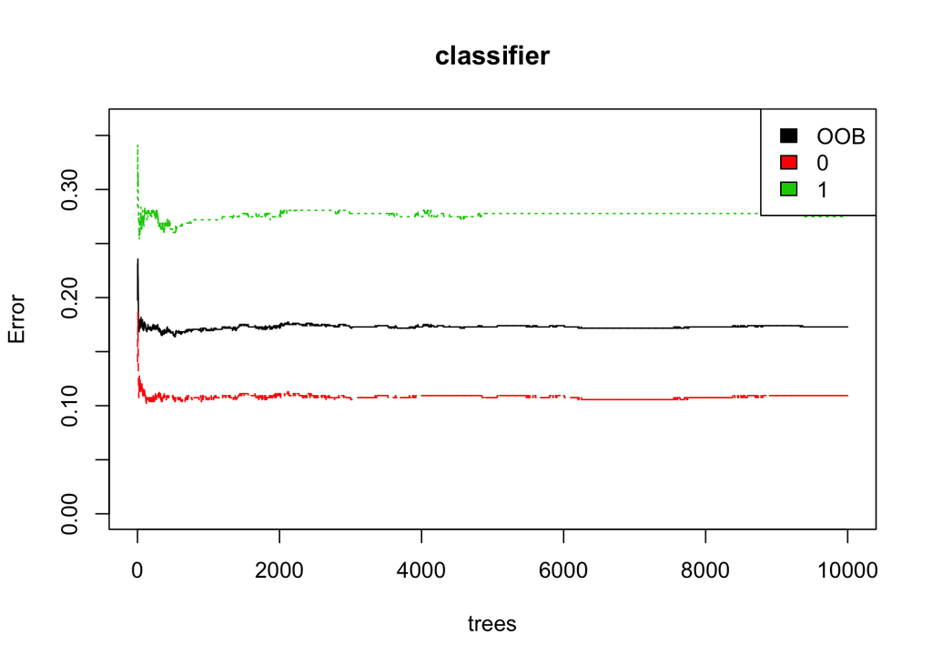

```r
classifier = randomForest(factor(Survived) ~ Pclass + Sex + Age  + SibSp + Parch + Embarked +
                            Ageset + Fare + hasCabin + Family_size + Title,
                   data= training_set, ntree = 10000)

# Show model error
plot(classifier, ylim=c(0,0.36))
legend('topright', colnames(classifier$err.rate), col=1:3, fill=1:3)
```

The black line shows the overall error rate which falls below 20%. The red and green lines show the error rate for ‘died’ and ‘survived’ respectively. We can see that right now we’re much more successful predicting death than we are survival.

Now we can check what’s the variable importance in the model used.

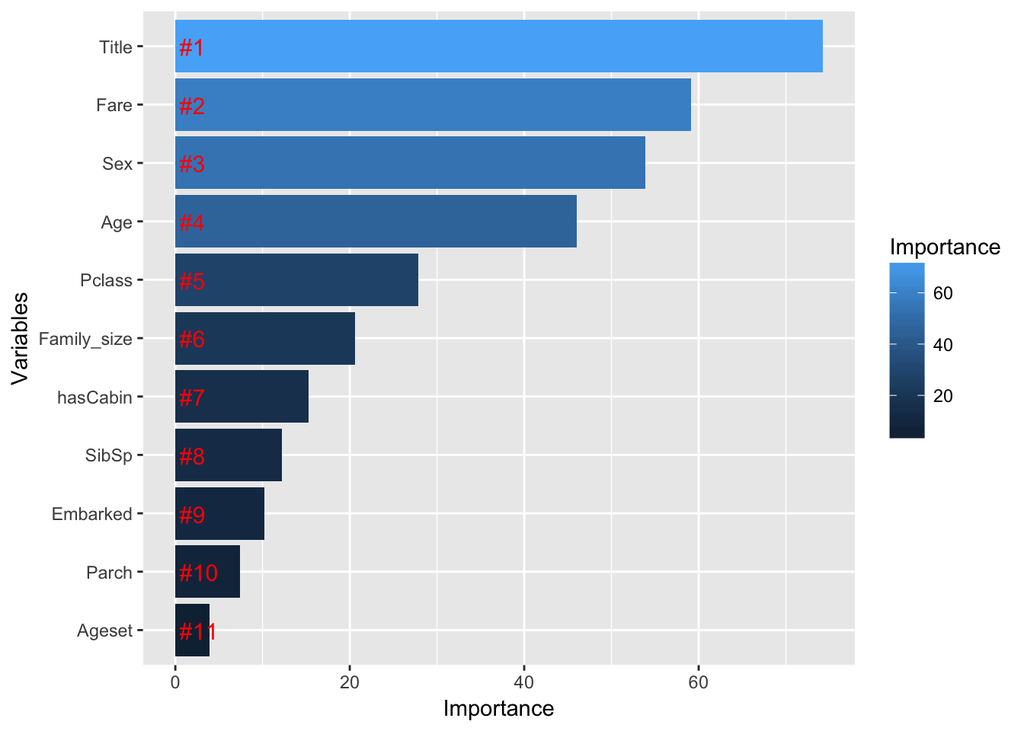

```r
# Get importance
importance    <- importance(classifier)
varImportance <- data.frame(Variables = row.names(importance),
                            Importance = round(importance[ ,'MeanDecreaseGini'],2))
library('dplyr')
# Create a rank variable based on importance
rankImportance <- varImportance %>%
  mutate(Rank = paste0('#',dense_rank(desc(Importance))))

# Use ggplot2 to visualize the relative importance of variables
ggplot(rankImportance, aes(x = reorder(Variables, Importance),
                           y = Importance, fill = Importance)) +
  geom_bar(stat='identity') +
  geom_text(aes(x = Variables, y = 0.5, label = Rank),
            hjust=0, vjust=0.55, size = 4, colour = 'red') +
  labs(x = 'Variables') +
  coord_flip()
```

Interesting to see that our new feature Title is the most important one!

To conclude, we can apply our model on the new test data and save the results as csv.

```r
# Predicting the Test set results
y_pred <- predict(classifier, test_set[-2], type='class')

#write result to csv
result <- data.frame(PassengerID = test_set$PassengerId, Survived = y_pred)
write.csv(x = result, file = 'result.csv', row.names = FALSE, quote = FALSE)
```